# Final Project

Christine Liu

R Studio Data Vizualization Class Spring 2019

Summary: In this plot, I am comparing if antibody surface staining is affected by the flow cytometry technique, fluorescent cell barcoding (FCB). Fluorescent cell barcoding is a multiplexing, cytometric platform that enables multiparameter analysis, minimizes inter-assay variations, and reduces antibody consumption. Each sample is labeled with a unique fluorescent signature (barcode). Up to nine samples can be combined into a single tube for antibody staining and undergo immunophenotyping. To determine if surface markers (CD3, CD4, CD8, CD20, and CD14) are altered in the barcoding process, I compare the percent of positive cells of patient samples that both underwent the barcoding process and were only surface stained (not barcoded). If the barcoding process does not affect immunophenotyping, the percent of positive cells should be comparable and closely fall on the line of best fit. There appears to be some variance, but in general, the barcoded and non-barcoded surface stainings are similar.

```r
library(tidyr)
library(tidyverse)
```

```r
library(rio)

NBCvsBC <- import('NBC vs BC DataViz Project CL.xlsx')

NBCvsBC <- as_tibble(NBCvsBC)
class(NBCvsBC)
```

```
## [1] "tbl_df"     "tbl"        "data.frame"
```

```r
NBCvsBC
```

```
## # A tibble: 45 x 3
##    Marker   NBC   FCB
##    <chr>  <dbl> <dbl>
##  1 CD3     62.2  63.1
##  2 CD3     62.7  63
##  3 CD3     77.6  63.9
##  4 CD3     79.4  62.2
##  5 CD3     76.6  63.7
##  6 CD3     80.4  63.8
##  7 CD3     82.4  62.3
##  8 CD3     76.3  62.2
##  9 CD3     75.8  62.9
## 10 CD4     43.8  45.6
## # … with 35 more rows
```

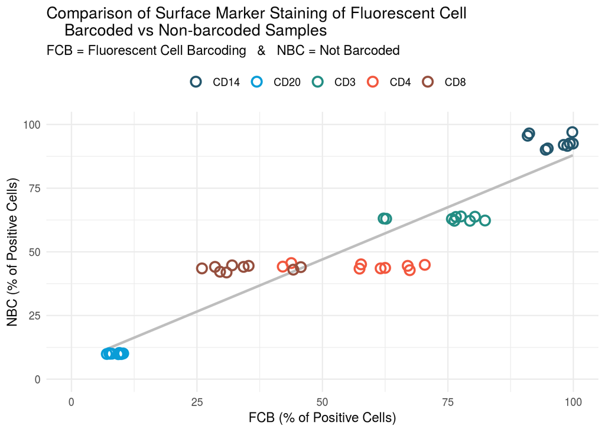

```r
ggplot(
  data = NBCvsBC,
  aes(x = NBC,
      y = FCB)
) + geom_smooth(method = "lm", color = "Grey", se = F) +
  aes(color = Marker) +
  scale_color_manual(name = '',
                     values = c("#24576D","#099DD7", "#248E84","#F2583F","#96503F")) +
  geom_point(shape = 1, size = 3, stroke = 1.25) +
  xlim(0,100) +
  ylim(0,100) +
  labs(
    x = "FCB (% of Positive Cells)",
    y = "NBC (% of Positive Cells)",
    title = "Comparison of Surface Marker Staining of Fluorescent Cell
    Barcoded vs Non-barcoded Samples",
    subtitle = "FCB = Fluorescent Cell Barcoding   &   NBC = Not Barcoded"
  ) +
  theme_minimal() +
  theme(legend.position = "top",
        legend.direction = "horizontal")
```